# Homework2

Eda Yıldız

26 Ekim 2018

## R Markdown

In this document we will analyze if there is a relation between the odds and matches results. Then we will focus on how we can compress images using PCA.

## Task 1-2 A

This task is to understand if we can obtain significant information regarding the game outcomes using the odd data from multiple bookmakers.

Final odds from the odd data is obtained. And in this homework only final odds for each bookmaker will be used. Unfortunately each bookmaker does not offer an odd for each betType/oddType. This is why in the PCA data we shoud deal with the NA values.

Deleting each match that has an NA value is an option. But this would lead to a huge data loss. This is why I believe replacing NA values is a better option. But at this point the replacement method become very important. Any wrong replacements may causes wrong results.

Any NA odd value for a bookmaker can be replaced with the help of the other bookmakers’ odd offers. In order to choose the replacement values in a better way I firstly classify the bookmakers. I created clusters consists of bookmakers that have relatively close odd offers.

From below you can see the use of kmeans function in order to cluster the bookmakers. the steps that are followed can be seen from below :

1. Bookmakers are clustered with respect to their 1x2 type Odd1 offers. So firstly the filtering is done.
2. In this type of offer for each match there are maximum 27 bookmakers that offer an odd.
3. Matches that has odds from 27 bookmakers are selected.
4. With the kmeans function Clusters are obtained.

```r
GameRes=FinalOdds[betType=="1x2" & oddtype=="odd1" ][,c("bookmaker","matchId","odd")]
GameRes[,count:=.N,matchId]

unique(GameRes$bookmaker)
```

```
##  [1] "10Bet"            "12BET"            "188BET"
##  [4] "1xBet"            "BetVictor"        "Betclic"
##  [7] "Betsafe"          "Betsson"          "Betway"
## [10] "ComeOn"           "Expekt"           "Interwetten"
## [13] "Paddy Power"      "Pinnacle"         "SBOBET"
## [16] "Sportingbet"      "Tipico"           "Unibet"
## [19] "William Hill"     "bet-at-home"      "bet365"
## [22] "bwin"             "mybet"            "youwin"
## [25] "888sport"         "Betfair"          "Betfair Exchange"
```

```r
GameRes[order(-count)]
```

```
##          bookmaker  matchId  odd count
##     1:       10Bet 06H610QA 2.55    27
##     2:       12BET 06H610QA 2.58    27
##     3:      188BET 06H610QA 2.58    27
##     4:       1xBet 06H610QA 2.63    27
##     5:    888sport 06H610QA 2.55    27
##    ---
## 78101: bet-at-home AR8CRWzb 1.95    22
## 78102:      bet365 AR8CRWzb 2.10    22
## 78103:        bwin AR8CRWzb 2.04    22
## 78104:       mybet AR8CRWzb 2.04    22
## 78105:      youwin AR8CRWzb 2.15    22
```

```r
MatchesForCluster=unique(GameRes[count==27]$matchId)
GameRes2=GameRes[matchId %in% MatchesForCluster][order(-odd)]

GameRes3=dcast(GameRes2, bookmaker~matchId,value.var="odd")

GameRes=na.omit(GameRes)

Cluster=kmeans(GameRes3[,c(2:359),with=F],4)
BookmakerClusters=as.data.table(cbind(GameRes3$bookmaker,Cluster$cluster))
```

After clustering bookmakers, as it is asked in the hw 5 Bookmakers are selected as it is done in the previous homework. Top 5 bookmakers that has the most odds offers are selected. In order to answer the question about the relation between the odss and the Game Results(Home,Away,Tie / Over-Under 2.5) the match results are obtained for both bettypes.

```r
MatchesCleaned[,OUResult:=as.numeric(ScoreSum>2.5) ]
MatchesCleaned=MatchesCleaned[ScoreHome>ScoreAway,GameResult:= 1 ]
MatchesCleaned=MatchesCleaned[ScoreAway>ScoreHome,GameResult:= 2 ]
MatchesCleaned=MatchesCleaned[ScoreAway==ScoreHome,GameResult:= 0 ]
```

Firstly bet365 bookmaker is chosen. Then the data is reshaped with the dcast function so that PCA can be applied.After dcast function we obtain the NA values. In order to replace the NA values the data is melted again. With the new data containing the NA values replacement is done according to the bookmakers that are in the same cluster with Bet365. After replacement the normalization is applied to the features so that we would not be affected from the odd ranges for different types of odds.

```r
Data2=Data[bookmaker=='bet365']
Data2$bookmaker=NULL

setnames(BookmakerClusters,'V1','bookmaker')

setnames(BookmakerClusters,'V2','Cluster')

setkey (FinalOdds,bookmaker)
setkey (BookmakerClusters,bookmaker)


NAReplacements=BookmakerClusters[FinalOdds][,Type:=paste0(betType,"_",oddtype,"_",totalhandicap)]
NAReplacements=NAReplacements[,list(Mean=mean(odd)),list(Type,Cluster)]

setkey(NAReplacements,Type,Cluster)

ShapedData=dcast(Data2,matchId ~   Type ,value.var="odd")

DataMelted =melt(ShapedData)
NewOdds=NAReplacements[Cluster== BookmakerClusters[bookmaker=='bet365']$Cluster]

setkey(NewOdds,Type)
setkey(DataMelted,variable)

NewOdds2=NewOdds[DataMelted][is.na(value),value:=Mean]

NewOdds2[,Min:=min(value),Type]
NewOdds2[,Max:=max(value),Type]
NewOdds2[,NormalizedOdd:=(value-Min)/(Max-Min) ]
NewOdds2[Max==Min,NormalizedOdd:=1 ]
```

After creating the data the PCA is applied. The code can be seen from below.

```r
setkey(GameResults,matchId)
setkey(ShapedData,matchId)

ShapedData=dcast(NewOdds2[],matchId ~ Type ,value.var="NormalizedOdd")


ShapedData=GameResults[ShapedData]

PCA=princomp(ShapedData[,c(4:109),with=F],cor=T)
```

```r
summary(PCA)
```

```
## Importance of components:
##                           Comp.1    Comp.2    Comp.3     Comp.4     Comp.5
## Standard deviation     5.7813192 4.9883639 3.4077680 2.94967219 2.19731338
## Proportion of Variance 0.3153175 0.2347526 0.1095555 0.08208081 0.04554893
## Cumulative Proportion  0.3153175 0.5500701 0.6596256 0.74170637 0.78725529
##                            Comp.6     Comp.7     Comp.8     Comp.9
## Standard deviation     2.05222565 1.71628568 1.40256215 1.18916230
## Proportion of Variance 0.03973236 0.02778902 0.01855831 0.01334063
## Cumulative Proportion  0.82698765 0.85477667 0.87333498 0.88667561
##                           Comp.10    Comp.11     Comp.12     Comp.13
## Standard deviation     1.08994752 1.04597967 0.917805477 0.889915154
## Proportion of Variance 0.01120741 0.01032145 0.007946857 0.007471217
## Cumulative Proportion  0.89788303 0.90820447 0.916151331 0.923622547
##                            Comp.14     Comp.15     Comp.16     Comp.17
## Standard deviation     0.816306266 0.720785588 0.714005101 0.648999097
## Proportion of Variance 0.006286377 0.004901244 0.004809465 0.003973583
## Cumulative Proportion  0.929908924 0.934810168 0.939619633 0.943593216
##                            Comp.18     Comp.19     Comp.20     Comp.21
## Standard deviation     0.605256586 0.603723329 0.562270740 0.539295988
## Proportion of Variance 0.003455996 0.003438508 0.002982532 0.002743775
## Cumulative Proportion  0.947049212 0.950487720 0.953470252 0.956214027
##                           Comp.22     Comp.23     Comp.24     Comp.25
## Standard deviation     0.52863026 0.522532037 0.493029038 0.480799943
## Proportion of Variance 0.00263632 0.002575847 0.002293185 0.002180836
## Cumulative Proportion  0.95885035 0.961426194 0.963719379 0.965900215
##                            Comp.26     Comp.27     Comp.28     Comp.29
## Standard deviation     0.472661183 0.460824158 0.422463873 0.414002680
## Proportion of Variance 0.002107628 0.002003386 0.001683733 0.001616964
## Cumulative Proportion  0.968007843 0.970011229 0.971694962 0.973311926
##                            Comp.30     Comp.31     Comp.32     Comp.33
## Standard deviation     0.398046390 0.394544580 0.381818655 0.378562429
## Proportion of Variance 0.001494726 0.001468542 0.001375335 0.001351977
## Cumulative Proportion  0.974806652 0.976275194 0.977650529 0.979002505
##                            Comp.34     Comp.35     Comp.36      Comp.37
## Standard deviation     0.372124303 0.358320728 0.349541632 0.3229122352
## Proportion of Variance 0.001306382 0.001211262 0.001152635 0.0009837011
## Cumulative Proportion  0.980308887 0.981520149 0.982672784 0.9836564854
##                             Comp.38      Comp.39     Comp.40      Comp.41
## Standard deviation     0.3145401194 0.3084166719 0.288684224 0.2840373563
## Proportion of Variance 0.0009333536 0.0008973664 0.000786213 0.0007611058
```

[output cut: 54 more lines]

```
## Standard deviation     6.005210e-02 5.424395e-02 5.265436e-02 5.156051e-02
## Proportion of Variance 3.402127e-05 2.775855e-05 2.615549e-05 2.508006e-05
## Cumulative Proportion  9.998279e-01 9.998556e-01 9.998818e-01 9.999069e-01
##                             Comp.98      Comp.99     Comp.100    Comp.101
## Standard deviation     4.909247e-02 4.273036e-02 4.000475e-02 3.86174e-02
## Proportion of Variance 2.273652e-05 1.722532e-05 1.509793e-05 1.40689e-05
## Cumulative Proportion  9.999296e-01 9.999468e-01 9.999619e-01 9.99976e-01
##                            Comp.102     Comp.103     Comp.104     Comp.105
## Standard deviation     3.625737e-02 3.213396e-02 1.208359e-02 7.280501e-03
## Proportion of Variance 1.240186e-05 9.741428e-06 1.377482e-06 5.000537e-07
## Cumulative Proportion  9.999884e-01 9.999981e-01 9.999995e-01 1.000000e+00
##                            Comp.106
## Standard deviation     3.683602e-08
## Proportion of Variance 1.280087e-17
## Cumulative Proportion  1.000000e+00
```

As you can see from the below plots for the over/under 2.5 game result can not be explained by the odds for different types of bets. We can not see a pattern that can help us to conclude that o/u 2.5 results can be ecplained by the odds.

But for the 1X2 et Type we can say that there is a pattern in the related plot. This means that the Game result (Home/Awat/Tie) can be explained by the odds.

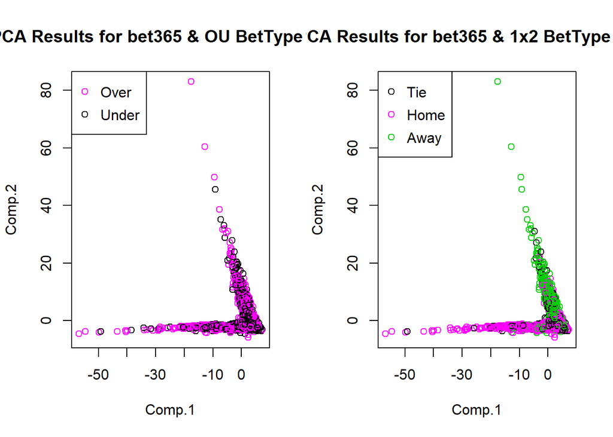

For other bookmakers calculations are done with similar way. Figures can be seen from below.

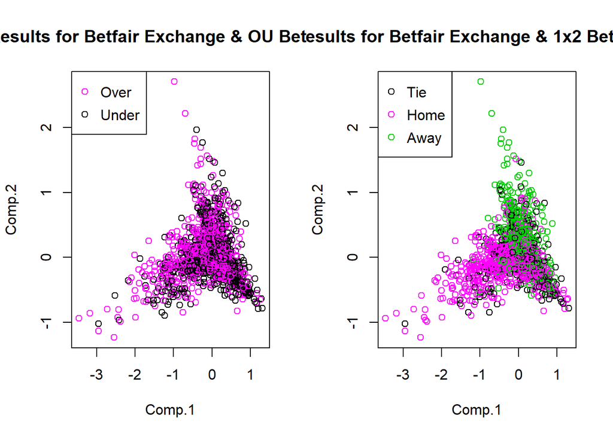

```r
Data2=Data[bookmaker=='Unibet']
Data2$bookmaker=NULL

setkey (FinalOdds,bookmaker)
setkey (BookmakerClusters,bookmaker)


NAReplacements=BookmakerClusters[FinalOdds][,Type:=paste0(betType,"_",oddtype,"_",totalhandicap)]
NAReplacements=NAReplacements[,list(Mean=mean(odd)),list(Type,Cluster)]

setkey(NAReplacements,Type,Cluster)

ShapedData=dcast(Data2,matchId ~   Type ,value.var="odd")

DataMelted =melt(ShapedData)
NewOdds=NAReplacements[Cluster== BookmakerClusters[bookmaker=='Unibet']$Cluster]

setkey(NewOdds,Type)
setkey(DataMelted,variable)

NewOdds2=NewOdds[DataMelted][is.na(value),value:=Mean]

NewOdds2[,Min:=min(value),Type]
NewOdds2[,Max:=max(value),Type]
NewOdds2[,NormalizedOdd:=(value-Min)/(Max-Min) ]
NewOdds2[Max==Min,NormalizedOdd:=1 ]


setkey(GameResults,matchId)
setkey(ShapedData,matchId)

ShapedData=dcast(NewOdds2[],matchId ~ Type ,value.var="NormalizedOdd")


ShapedData=GameResults[ShapedData]

x=dim(ShapedData)[2]
PCA=princomp(ShapedData[,c(4:133),with=F])
```

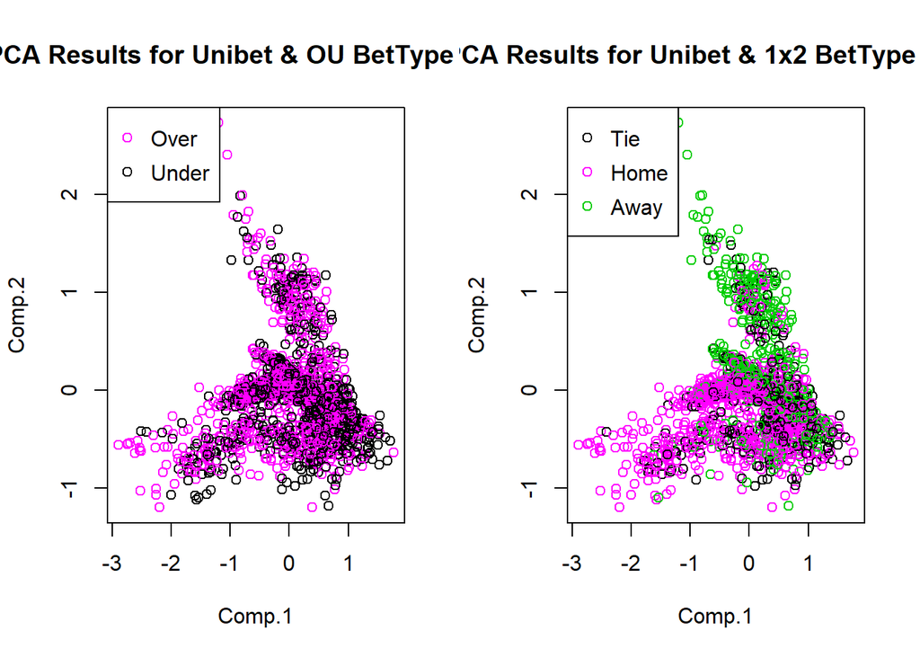

```r
Data2=Data[bookmaker=='1xBet']
Data2$bookmaker=NULL


setkey (FinalOdds,bookmaker)
setkey (BookmakerClusters,bookmaker)


NAReplacements=BookmakerClusters[FinalOdds][,Type:=paste0(betType,"_",oddtype,"_",totalhandicap)]
NAReplacements=NAReplacements[,list(Mean=mean(odd)),list(Type,Cluster)]

setkey(NAReplacements,Type,Cluster)

ShapedData=dcast(Data2,matchId ~   Type ,value.var="odd")

DataMelted =melt(ShapedData)
NewOdds=NAReplacements[Cluster== BookmakerClusters[bookmaker=='1xBet']$Cluster]

setkey(NewOdds,Type)
setkey(DataMelted,variable)

NewOdds2=NewOdds[DataMelted][is.na(value),value:=Mean]

NewOdds2[,Min:=min(value),Type]
NewOdds2[,Max:=max(value),Type]
NewOdds2[,NormalizedOdd:=(value-Min)/(Max-Min) ]
NewOdds2[Max==Min,NormalizedOdd:=1 ]


setkey(GameResults,matchId)
setkey(ShapedData,matchId)

ShapedData=dcast(NewOdds2[],matchId ~ Type ,value.var="NormalizedOdd")


ShapedData=GameResults[ShapedData]


x=dim(ShapedData)[2]
PCA=princomp(ShapedData[,c(4:145),with=F])
```

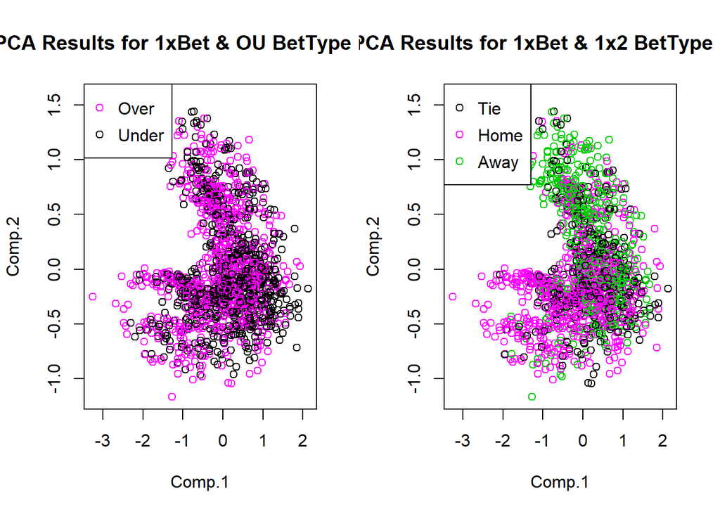

```r
Data2=Data[bookmaker=='BetVictor']
Data2$bookmaker=NULL


setkey (FinalOdds,bookmaker)
setkey (BookmakerClusters,bookmaker)


NAReplacements=BookmakerClusters[FinalOdds][,Type:=paste0(betType,"_",oddtype,"_",totalhandicap)]
NAReplacements=NAReplacements[,list(Mean=mean(odd)),list(Type,Cluster)]

setkey(NAReplacements,Type,Cluster)

ShapedData=dcast(Data2,matchId ~   Type ,value.var="odd")

DataMelted =melt(ShapedData)
NewOdds=NAReplacements[Cluster== BookmakerClusters[bookmaker=='BetVictor']$Cluster]

setkey(NewOdds,Type)
setkey(DataMelted,variable)

NewOdds2=NewOdds[DataMelted][is.na(value),value:=Mean]

NewOdds2[,Min:=min(value),Type]
NewOdds2[,Max:=max(value),Type]
NewOdds2[,NormalizedOdd:=(value-Min)/(Max-Min) ]
NewOdds2[Max==Min,NormalizedOdd:=1 ]


setkey(GameResults,matchId)
setkey(ShapedData,matchId)

ShapedData=dcast(NewOdds2[],matchId ~ Type ,value.var="NormalizedOdd")


ShapedData=GameResults[ShapedData]

x=dim(ShapedData)[2]
PCA=princomp(ShapedData[,c(4:115),with=F],cor=T)
```

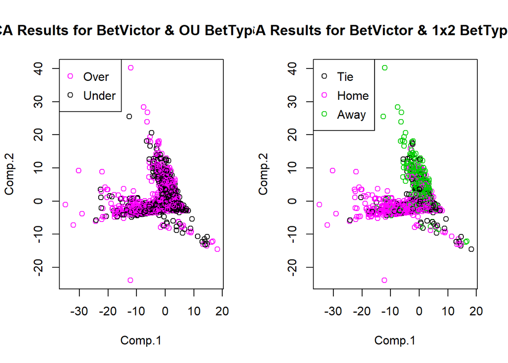

We can also see how components affect the result from below. Barchart representation help us to comment on the effect (negative or positive) of components.

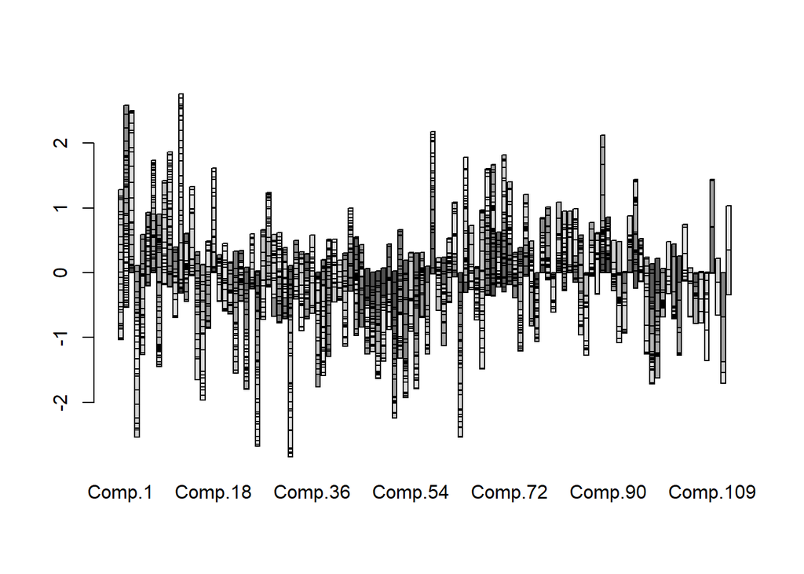

## Task 1B

For this task we follow the same strategy by applying multidimensional scaling (MDS). Since we are given a data matrix. We need to transform this information to distance matrix.

Firstly distance matrix is calculated with the dist function for both Manhattan and Eucledian distances.Then these distances are given to the cmdscale function as input. You can see the related code part below.

```r
EucDistance=dist(ShapedDataTaskB[,c(4:109),with=F],diag=T,upper = T)
ManhattanDistance=dist(ShapedDataTaskB[,c(4:109),with=F],method="manhattan")

mds=cmdscale(EucDistance)
mdsManhattan=cmdscale(ManhattanDistance)
```

The distance between the matches are calculated based on the odds offerred. From below We can see that the 1x2 BetType can be explaned with the odds clearly. The pattern can be seen as it is in PCA.

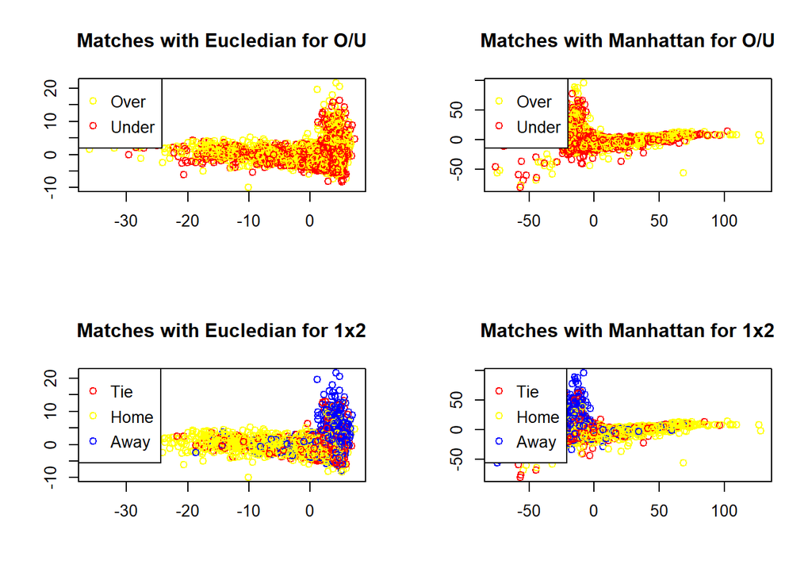

## Task 3

In this task, you are requested to perform certain operations on images. The aim is to compress images using PCA.

I took a picture of Harry Potter books, then resize it to 512x512.

Step 1: The image is read with the readJPEG function as can be seen from below.

```r
image=readJPEG("C:/Users/eda/Downloads/imagee.jpg", native = FALSE)
```

Step 2: The structure of the picture stored is a number array with the dimensions [1:512, 1:512, 1:3] the structure is obtained with the help of the code:

```r
str(image)
```

```
##  num [1:512, 1:512, 1:3] 0.608 0.612 0.624 0.62 0.624 ...
```

a.Displaying the Image with the code

[figure not shown]

```r
plot(0:5+0.5, 0:5+0.5, type="n",ANN=FALSE,axes = FALSE)
rasterImage(image, 0.5, 0.5, 5.5, 5.5, interpolate=FALSE,axes=FALSE)
```

b.Display each channel

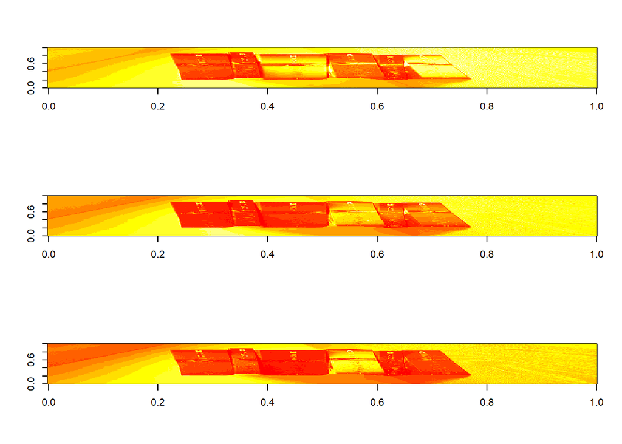

```r
par(mfrow=c(3,1))

r <- image(image[,,1])
g <-image(image[,,2])
b <- image(image[,,3])
```

3. Creating Noisy Image

I use runif function to generate genarate uniformly distrubited random numbers between 0 and 0.1 for each channel, z1,z2,z3.

Then I create a sparse array having the same sizes with the real image and add the random numbers to the real pixel values to create noisy image.Then I capped the values with maximum 1 since the images stores numbers between 0 and 1.

```r
z1=runif(512*512, min=0, max=0.1)
z2=runif(512*512, min=0, max=0.1)
z3=runif(512*512, min=0, max=0.1)


imageNoised <- array(rep(0, 512*512*3), c(512, 512, 3))

imageNoised[,,1]=image[,,1]+matrix(unlist(z1), ncol = 512, byrow = TRUE)
imageNoised[,,2]=image[,,2]+matrix(unlist(z2), ncol = 512, byrow = TRUE)
imageNoised[,,3]=image[,,3]+matrix(unlist(z3), ncol = 512, byrow = TRUE)

A=imageNoised[,,1]
A[A>1]=rep(1,length(A[A>1]) )
B=imageNoised[,,2]
B[B>1]=rep(1,length(B[B>1]) )
C=imageNoised[,,3]
C[C>1]=rep(1,length(C[C>1]) )

imageNoised[,,1]=A
imageNoised[,,2]=B
imageNoised[,,3]=C
```

Noisy image can be seen from below:

[figure not shown]